# Отчёт по лабораторной работе №10

Простейший вариант

Бызова Мария Олеговна

2025-11-04

# Цель работы

## Цель работы

Целью данной лабораторной работы является приобретение практических навыков по конфигурированию SMTP-сервера в части настройки аутентификации.

# Выполнение лабораторной работы

## Настройка LMTP в Dovecot

На виртуальной машине server вошли под пользователем и открыли терминал. Перешли в режим суперпользователя (рис. 1).

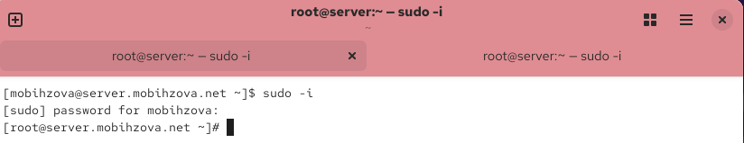

Рисунок 1: Переход в режим суперпользователя

## Настройка LMTP в Dovecot

Запустили мониторинг работы почтовой службы (рис. 2).

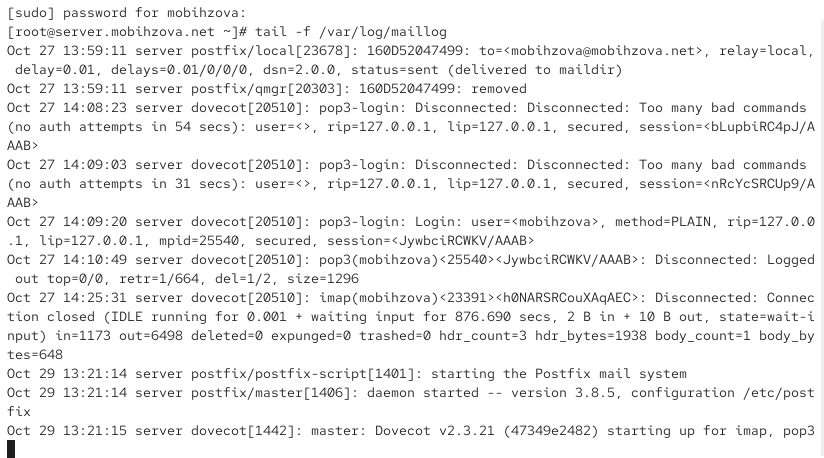

Рисунок 2: Запуск мониторинга почтовой службы

## Настройка LMTP в Dovecot

Добавили в список протоколов, с которыми может работать Dovecot, протокол LMTP (рис. 3).

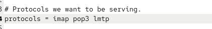

Рисунок 3: Добавление протокола LMTP в файл конфигурации Dovecot

## Настройка LMTP в Dovecot

Настроили в Dovecot сервис lmtp для связи с Postfix (рис. 4).

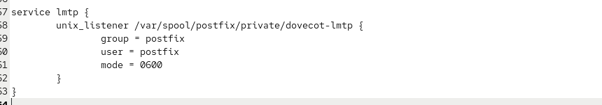

Рисунок 4: Настройка сервиса lmtp в Dovecot

## Настройка LMTP в Dovecot

Переопределили в Postfix передачу сообщений через заданный unix-сокет (рис. 5).

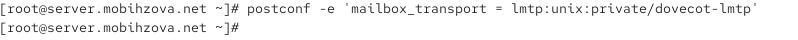

Рисунок 5: Настройка mailbox_transport в Postfix

## Настройка LMTP в Dovecot

Задали формат имени пользователя для аутентификации (рис. 6).

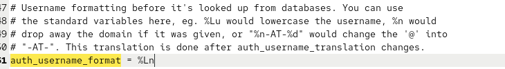

Рисунок 6: Настройка формата имени пользователя

## Настройка LMTP в Dovecot

Перезапустили Postfix и Dovecot (рис. 7).

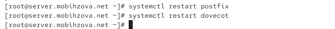

Рисунок 7: Перезапуск Postfix и Dovecot

## Настройка LMTP в Dovecot

Отправили письмо с клиента для тестирования LMTP (рис. 8).

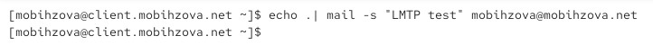

Рисунок 8: Отправка тестового письма

## Настройка LMTP в Dovecot

Проверили доставку письма в почтовый ящик на сервере (рис. 9).

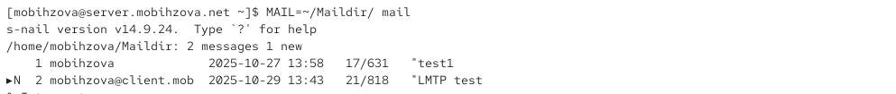

Рисунок 9: Проверка почтового ящика

## Настройка LMTP в Dovecot

Просмотрели логи доставки письма (рис. 10).

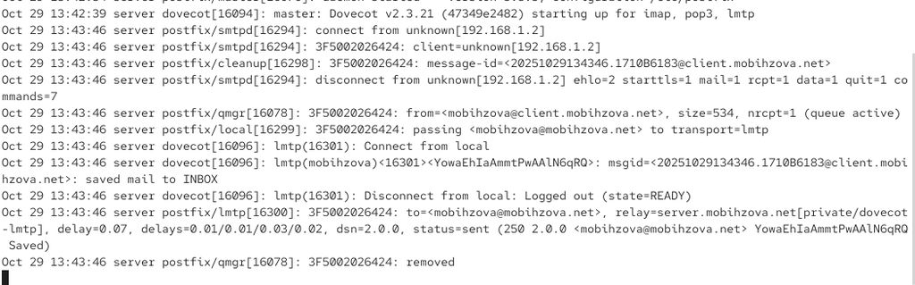

Рисунок 10: Логи доставки письма через LMTP

## Настройка SMTP-аутентификации

Определили службу аутентификации пользователей в Dovecot (рис. 11).

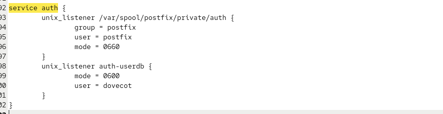

Рисунок 11: Настройка службы аутентификации

## Настройка SMTP-аутентификации

Задали тип аутентификации SASL и путь к unix-сокету в Postfix (рис. 12).

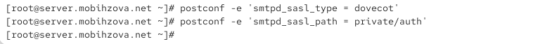

Рисунок 12: Настройка SASL аутентификации в Postfix

## Настройка SMTP-аутентификации

Настроили ограничения для получателей в Postfix (рис. 13).

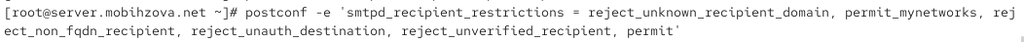

Рисунок 13: Настройка ограничений получателей

## Настройка SMTP-аутентификации

Настроили мастер-процесс Postfix для включения SASL-аутентификации (рис. 15).

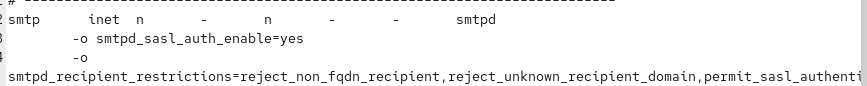

Рисунок 15: Настройка master.cf для SASL

## Настройка SMTP-аутентификации

Перезапустили Postfix и Dovecot (рис. 16).

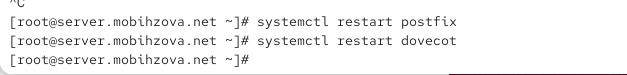

Рисунок 16: Перезапуск служб после настройки SASL

## Настройка SMTP-аутентификации

Установили telnet на клиенте (рис. 17).

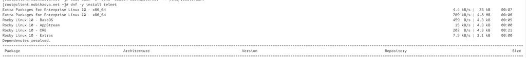

Рисунок 17: Установка telnet на клиенте

## Настройка SMTP-аутентификации

Сгенерировали строку для аутентификации (рис. 18).

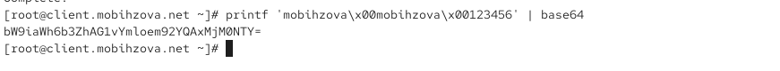

Рисунок 18: Генерация строки аутентификации

## Настройка SMTP-аутентификации

Протестировали аутентификацию через telnet (рис. 19).

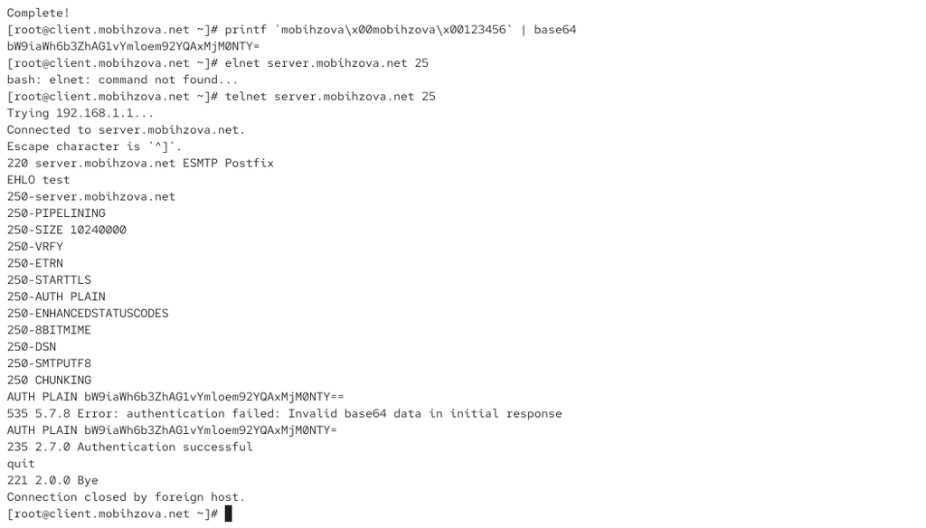

Рисунок 19: Тестирование аутентификации через telnet

## Настройка SMTP over TLS

Скопировали сертификаты Dovecot в каталог TLS (рис. 20).

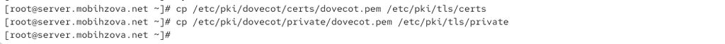

Рисунок 20: Копирование сертификатов TLS

## Настройка SMTP over TLS

Настроили параметры TLS в Postfix (рис. 21).

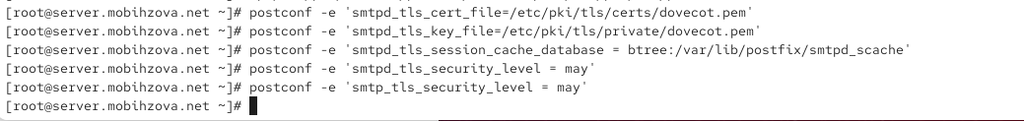

Рисунок 21: Настройка параметров TLS

## Настройка SMTP over TLS

Настроили порт 587 для Submission с TLS (рис. 22).

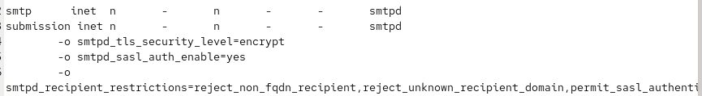

Рисунок 22: Настройка порта 587 в master.cf

## Настройка SMTP over TLS

Настроили межсетевой экран для работы с smtp-submission (рис. 23).

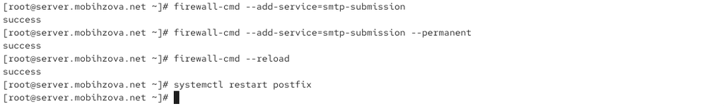

Рисунок 23: Настройка межсетевого экрана

## Настройка SMTP over TLS

Протестировали подключение через openssl s_client (рис. 24).

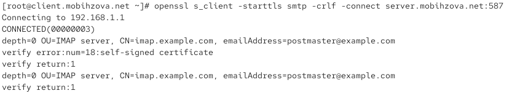

Рисунок 24: Тестирование TLS подключения

## Настройка SMTP over TLS

Выполнили команду EHLO для проверки возможностей сервера (рис. 25).

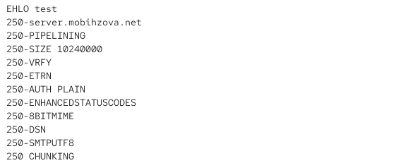

Рисунок 25: Проверка возможностей сервера через EHLO

## Настройка SMTP over TLS

Протестировали аутентификацию через TLS соединение (рис. 26).

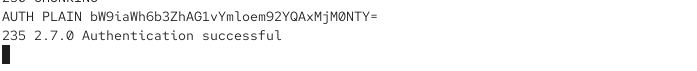

Рисунок 26: Аутентификация через TLS

## Настройка SMTP over TLS

Настроили почтовый клиент Evolution для работы с SMTP (рис. 27).

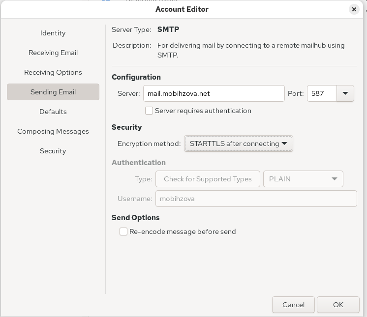

Рисунок 27: Настройка Evolution для SMTP

## Настройка SMTP over TLS

Создали и отправили тестовое письмо через Evolution (рис. 28).

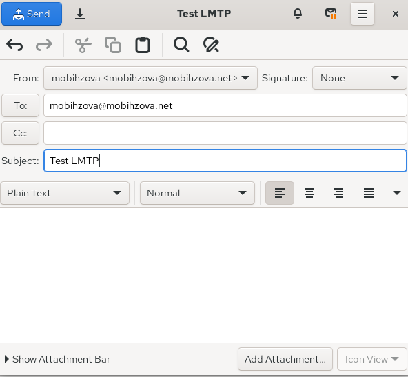

Рисунок 28: Создание тестового письма

## Настройка SMTP over TLS

Ввели учетные данные при запросе аутентификации (рис. 29).

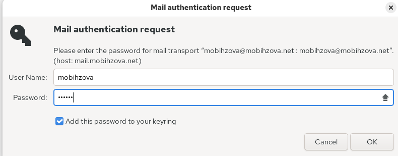

Рисунок 29: Ввод учетных данных аутентификации

## Настройка SMTP over TLS

Проверили доставку письма в почтовый ящик (рис. 30).

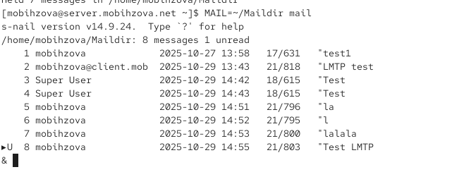

Рисунок 30: Проверка доставки письма

## Внесение изменений в настройки внутреннего окружения виртуальной машины

Скопировали конфигурационные файлы в директорию Vagrant (рис. 31).

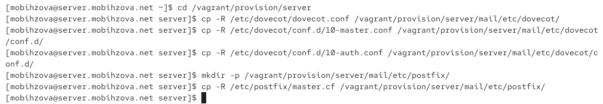

Рисунок 31: Копирование конфигурационных файлов

## Внесение изменений в настройки внутреннего окружения виртуальной машины

Обновили скрипт mail.sh для автоматической настройки (рис. 32).

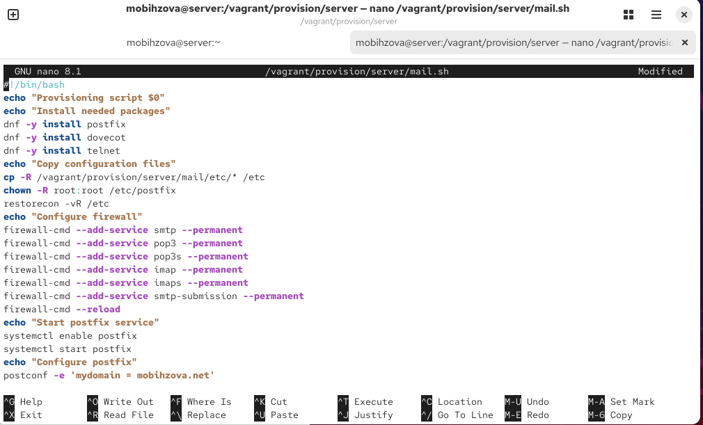

Рисунок 32: Обновление скрипта mail.sh

## Внесение изменений в настройки внутреннего окружения виртуальной машины

Обновили скрипт на клиенте (рис. 33).

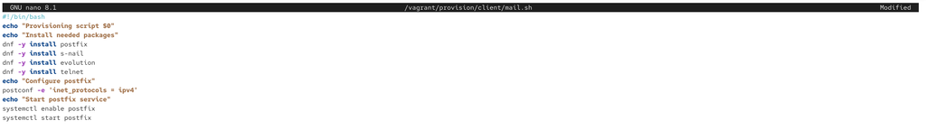

Рисунок 33: Обновление скрипта на клиенте

# Выводы

## Выводы

В ходе данной лабораторной работы я приобрела практические навыки по конфигурированию SMTP-сервера в части настройки аутентификации.